# Time Series Modeling

### Javier Lopez

> 1. Import Libraries/Packages
> 2. ARIMA Model Selection  
>    2.1. Data Exploration  
>    2.2. Stationarity Analysis  
>    2.2. Seasonality Analysis  
>    2.2. Autocorrelation Analysis  
>    2.2. Spectral Density  
>    2.2. Time Series Decomposition  
>    2.2. ARIMA Modeling
> 3. Forecast Prediction Interval
> 4. Justification: Forecast Length
> 5. Model Evaluation Procedure  
>    5.1. Error Metric
> 6. Visualization: Final Model Forecast vs Test Set
> 7. Recommended Course of Action
> 8. Projected Revenue: Year 3, Month 1

## 1. Import Libraries/Packages

```python
import pandas as pd
import numpy as np
import matplotlib.pyplot as plt
%matplotlib inline
plt.rcParams['figure.figsize'] = [16,10]
import seaborn as sns
sns.set_palette('colorblind')
import warnings
warnings.filterwarnings('ignore')

from statsmodels.tsa.stattools import adfuller
from statsmodels.graphics.tsaplots import plot_acf, plot_pacf, pacf
from statsmodels.tsa.seasonal import seasonal_decompose
from statsmodels.tsa.arima.model import ARIMA
from sklearn.model_selection import train_test_split
from scipy.signal import periodogram
from scipy.stats import linregress
from pmdarima import auto_arima
from sklearn.metrics import mean_squared_error as mse
```

```python
# Load the data
df = pd.read_csv('teleco_time_series.csv')
```

```python
# Review data shape
df.info()
```

```
<class 'pandas.core.frame.DataFrame'>
RangeIndex: 731 entries, 0 to 730
Data columns (total 2 columns):
 #   Column   Non-Null Count  Dtype
---  ------   --------------  -----
 0   Day      731 non-null    int64
 1   Revenue  731 non-null    float64
dtypes: float64(1), int64(1)
memory usage: 11.5 KB
```

Scroll Up

## 2. ARIMA Model Selection

#### Data Exploration:

> We started by visualizing the revenue data for Year 1 and Year 2 separately, gaining an initial understanding of any noticeable trends or patterns.

#### Stationarity Analysis:

> We examined stationarity by plotting the rolling mean and standard deviation of the observed data. This helped us identify any underlying trends. We also checked for stationarity by differencing the data.

#### Seasonality Analysis:

> We analyzed the seasonal subseries by grouping the data into different time periods (Year, Quarter, Month, Week). This allowed us to identify any recurring patterns or seasonality present in the data.

#### Autocorrelation Analysis:

> We plotted the autocorrelation function (ACF) and partial autocorrelation function (PACF) to examine the correlation between observations and their lags. These plots helped us determine the order of the ARIMA model.

#### Spectral Density:

> We calculated and plotted the spectral density using the periodogram, enabling us to identify any dominant frequencies or periodicity in the data.

#### Time Series Decomposition:

> We decomposed the time series into its components (observed, trend, seasonal) using the seasonal_decompose function. This decomposition provided insights into the underlying trends and seasonality in the data.

#### ARIMA Modeling:

> We fit an ARIMA model to the differenced data, utilizing the identified order of (1, 1, 0). We then generated forecasts for the last 30 days of the time series using the model. We compared the forecasted values to the test series to assess the model's accuracy, calculating the root mean squared error (RMSE) as a measure of forecast error.

## By following this approach of data exploration, stationarity and seasonality analysis, autocorrelation analysis, spectral density analysis, time series decomposition, and ARIMA modeling, we arrived at an appropriate ARIMA model selection for the given time series data.

Scroll Up

### 2.1. Data Exploration

#### Data Visualization:

> - We created a pandas Series object, ts, using the daily revenue values from the DataFrame df, with the index set as the 'Day' column. This step is crucial for organizing the data in a time-dependent manner.
> - We used the seaborn library's lineplot function to create two line plots. The first plot represents the revenue data for the first year, while the second plot represents the revenue data for the second year. By plotting the data separately for each year, we can observe any potential differences or trends between the two periods.
> - To emphasize the distinction between the two years, we used the fill_between function from matplotlib to shade the areas beneath each line plot. This shading visually separates the two periods, making it easier to compare their revenue trends.

#### Findings:

> - We can observe positive revenue trends for both years.
> - There is no discernible repetitive pattern in the line plots. This provides an initial indication that there is no seasonality component in the time series data.

```python
# Create a pandas series object from the time-series data
ts = pd.Series(df['Revenue'].values, index=df['Day'])
```

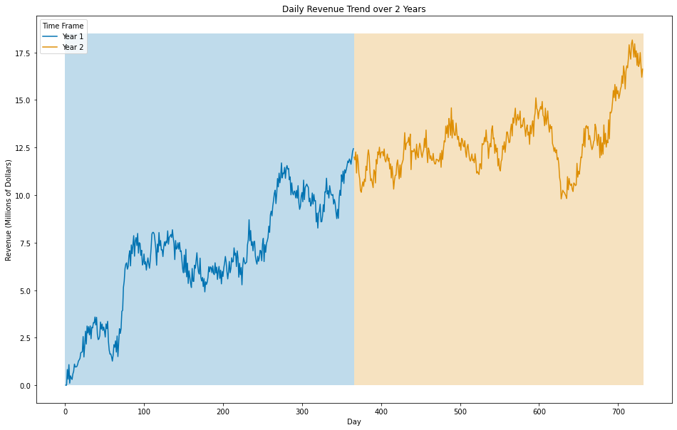

```python
# Plot the first year of revenue
sns.lineplot(data=ts[:365])

# Plot the second year of revenue
sns.lineplot(data=ts[365:])

# Shade each section of the plot
plt.fill_between([0, 366], [0], [18.5], alpha=0.25)
plt.fill_between([366, 732], [0], [18.5], alpha=0.25)

# Set titles and labels
plt.title('Daily Revenue Trend over 2 Years')
plt.ylabel('Revenue (Millions of Dollars)')
plt.legend(['Year 1', 'Year 2'], title='Time Frame')
plt.show()
```

Scroll Up

### 2.2. Stationarity Analysis

> **Augmented Dickey-Fuller (ADF) Test:**
> - The ADF test is commonly used to check for stationarity in time series data. We defined a function adf_test that performs the ADF test and displays the results.
> - The test produces a test statistic and a p-value, which are compared to critical values at different significance levels (1%, 5%, and 10%) to determine stationarity.
> - The Null Hypothesis states that the time series has a unit root and is non-stationary, while the Alternative Hypothesis states that the time series does not have a unit root and is stationary.

> **Rolling Mean and Standard Deviation:**
> - To visually analyze trends in the data, we plotted the observed data along with the rolling mean and standard deviation. The rolling mean helps identify any overall increasing or decreasing trends, while the rolling standard deviation provides insights into the data's variability.

> **Differencing:**
> - To make the data stationary, we applied differencing by computing the first-order difference of the time series. This involves taking the difference between consecutive observations.

> **ADF Test on Differenced Data:**
> - We performed the ADF test on the differenced data to check for stationarity.

#### Findings:

> - Based on the ADF test results, the original time series data does not appear to be stationary.
> - After applying differencing, the differenced data shows evidence of stationarity. This suggests that differencing may be necessary to make the data stationary and suitable for further time series analysis and modeling.

```python
# Define Augmented Dickey-Fuller (ADF) test function as per statsmodels
def adf_test(timeseries):
    print("Results of Dickey-Fuller Test:")
    dftest = adfuller(timeseries, autolag="AIC")
    dfoutput = pd.Series(
        dftest[0:4],
        index=[
            "Test Statistic",
            "p-value",
            "#Lags Used",
            "Number of Observations Used",
        ],
    )
    for key, value in dftest[4].items():
        dfoutput["Critical Value (%s)" % key] = value
    print(dfoutput)
```

```python
# Get the ADF test results
adf_test(ts)
```

```
Results of Dickey-Fuller Test:
Test Statistic                  -1.924612
p-value                          0.320573
#Lags Used                       1.000000
Number of Observations Used    729.000000
Critical Value (1%)             -3.439352
Critical Value (5%)             -2.865513
Critical Value (10%)            -2.568886
dtype: float64
```

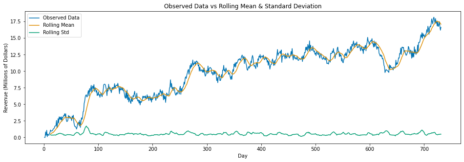

```python
plt.rcParams['figure.figsize'] = [16,5]
# Plot the rolling mean and standard deviation to spot trends
plt.plot(ts, label='Observed Data')
plt.plot(ts.rolling(window=12).mean(), label='Rolling Mean')
plt.plot(ts.rolling(window=12).std(), label='Rolling Std')
plt.title('Observed Data vs Rolling Mean & Standard Deviation')
plt.xlabel('Day')
plt.ylabel('Revenue (Millions of Dollars)')
plt.legend()
plt.show()
plt.rcParams['figure.figsize'] = [16,10]
```

```python
# Difference the data
diff = np.diff(ts)
```

```python
# Create a pandas series object from the differenced time-series data
diff_ts = pd.Series(diff, index=ts.index[:-1])
```

```python
# Test the difference data for stationarity
adf_test(diff_ts)
```

```
Results of Dickey-Fuller Test:
Test Statistic                 -44.874527
p-value                          0.000000
#Lags Used                       0.000000
Number of Observations Used    729.000000
Critical Value (1%)             -3.439352
Critical Value (5%)             -2.865513
Critical Value (10%)            -2.568886
dtype: float64
```

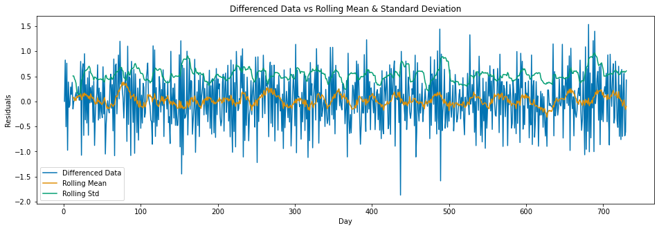

```python
plt.rcParams['figure.figsize'] = [16,5]
# Plot the rolling mean and standard deviation of the differenced data
plt.plot(diff_ts, label='Differenced Data')
plt.plot(diff_ts.rolling(window=12).mean(), label='Rolling Mean')
plt.plot(diff_ts.rolling(window=12).std(), label='Rolling Std')
plt.title('Differenced Data vs Rolling Mean & Standard Deviation')
plt.xlabel('Day')
plt.ylabel('Residuals')
plt.legend()
plt.show()
plt.rcParams['figure.figsize'] = [16,10]
```

```python
# Create seasonal subseries from the Day column
df['Year'] = df['Day'].apply(lambda d: 1 if d <= 365 else 2)
df['Quarter'] = (((df['Day'] - 1) // 91.3125 % 4) + 1).astype(int)
df['Month'] = (((df['Day'] - 1) // 30.437 % 12) + 1).astype(int)
df['Week'] = (((df['Day'] - 1) // 7 % 52.1429) + 1).astype(int)
```

Scroll Up

### 2.3. Seasonality Analysis

> **Seasonal Subseries:**
> - We created seasonal subseries by grouping the data based on different time periods (year, quarter, month, and week). This helps in analyzing any seasonal patterns or trends within each subseries.
> - We plotted the revenue trends in the seasonal subseries, including subseries based on year, quarter, month, and week. This analysis helps us observe any seasonality patterns and trends within the data.
> - By examining these subseries plots, we can gain insights into the presence of seasonality and how it varies across different time periods.

> **Auto-ARIMA Model:**
> - We used the auto_arima function to automatically find the optimal p, d, q values for the ARIMA model.

#### Findings:

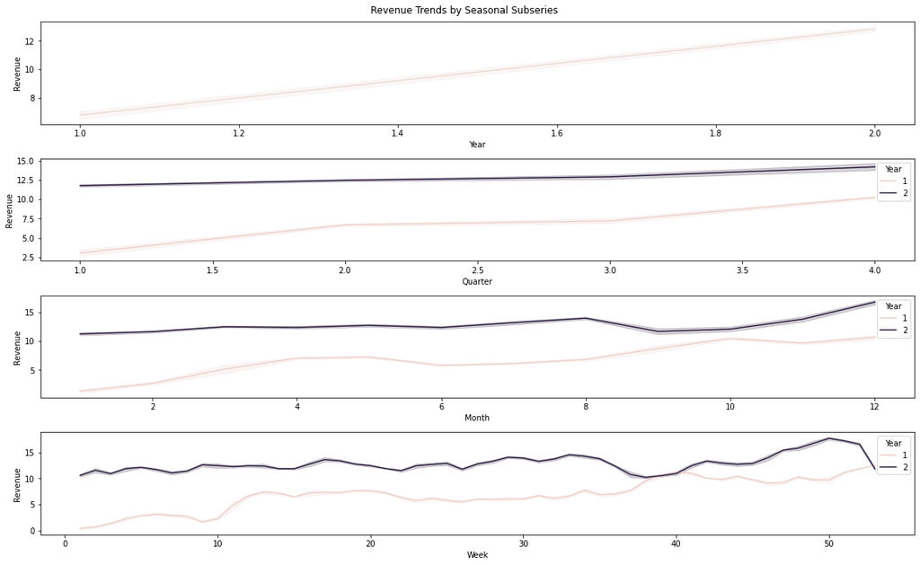

```python
# Plot seasonal subseries to observe seasonality overview
fig, ax = plt.subplots(4)
plt.suptitle('Revenue Trends by Seasonal Subseries')
sns.lineplot(x='Year', y='Revenue', data=df, ax=ax[0], color='#EBDBD6')
sns.lineplot(x='Quarter', y='Revenue', hue='Year', data=df, ax=ax[1])
sns.lineplot(x='Month', y='Revenue', hue='Year', data=df, ax=ax[2])
sns.lineplot(x='Week', y='Revenue', hue='Year', data=df, ax=ax[3])
plt.tight_layout()
```

```python
# Use auto-arima to evaluate seasonality and find the optimal p, d, q values
stepwise_fit = auto_arima(ts, trace=True, supress_warnings=True)
```

```
Performing stepwise search to minimize aic
 ARIMA(2,1,2)(0,0,0)[0] intercept   : AIC=987.305, Time=0.38 sec
 ARIMA(0,1,0)(0,0,0)[0] intercept   : AIC=1162.819, Time=0.04 sec
 ARIMA(1,1,0)(0,0,0)[0] intercept   : AIC=983.122, Time=0.06 sec
 ARIMA(0,1,1)(0,0,0)[0] intercept   : AIC=1019.369, Time=0.07 sec
 ARIMA(0,1,0)(0,0,0)[0]             : AIC=1162.139, Time=0.03 sec
 ARIMA(2,1,0)(0,0,0)[0] intercept   : AIC=985.104, Time=0.08 sec
 ARIMA(1,1,1)(0,0,0)[0] intercept   : AIC=985.106, Time=0.05 sec
 ARIMA(2,1,1)(0,0,0)[0] intercept   : AIC=986.045, Time=0.30 sec
 ARIMA(1,1,0)(0,0,0)[0]             : AIC=984.710, Time=0.03 sec

Best model:  ARIMA(1,1,0)(0,0,0)[0] intercept
Total fit time: 1.051 seconds
```

```python
# Print the model summary
stepwise_fit.summary()
```

SARIMAX Results

| Dep. Variable: | y | No. Observations: | 731 |
| --- | --- | --- | --- |
| Model: | SARIMAX(1, 1, 0) | Log Likelihood | -488.561 |
| Date: | Tue, 06 Jun 2023 | AIC | 983.122 |
| Time: | 10:21:14 | BIC | 996.901 |
| Sample: | 0 | HQIC | 988.438 |
|  | - 731 |  |  |
| Covariance Type: | opg |  |  |

|  | coef | std err | z | P>\|z\| | [0.025 | 0.975] |
| --- | --- | --- | --- | --- | --- | --- |
| intercept | 0.0332 | 0.018 | 1.895 | 0.058 | -0.001 | 0.068 |
| ar.L1 | -0.4692 | 0.033 | -14.296 | 0.000 | -0.534 | -0.405 |
| sigma2 | 0.2232 | 0.013 | 17.801 | 0.000 | 0.199 | 0.248 |

| Ljung-Box (L1) (Q): | 0.00 | Jarque-Bera (JB): | 2.05 |
| --- | --- | --- | --- |
| Prob(Q): | 0.96 | Prob(JB): | 0.36 |
| Heteroskedasticity (H): | 1.02 | Skew: | -0.02 |
| Prob(H) (two-sided): | 0.85 | Kurtosis: | 2.74 |

Warnings:  
[1] Covariance matrix calculated using the outer product of gradients (complex-step).

Scroll Up

### 2.4. Autocorrelation Analysis

> **ACF Plot:**
> - The ACF plot shows the autocorrelation values at different lags.
> - The ACF values range between 1 and -1, with 1 indicating a strong positive autocorrelation and -1 indicating a strong negative autocorrelation.

> **PACF Plot:**
> - The PACF plot shows the partial autocorrelation values at different lags, which represent the correlation between the observations and their lagged values while accounting for the influence of intermediate lags.
> - The PACF values also range between 1 and -1.

#### Findings:

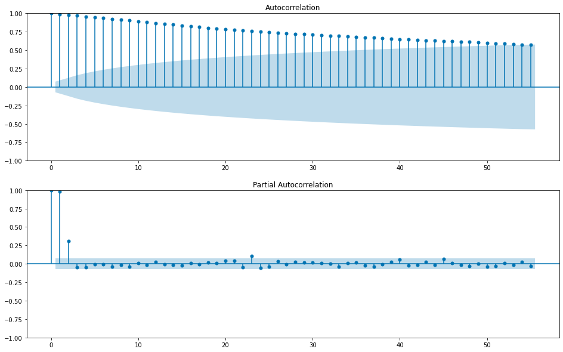

```python
# Visualize the acf and pacf plots
fig, ax = plt.subplots(2)
plot_acf(ts, lags=55, ax=ax[0])
plot_pacf(ts, lags=55, ax=ax[1])
plt.show()
```

Scroll Up

### 2.5. Spectral Density Analysis

> **Dominant frequencies:**
> - The plot shows peaks at certain frequencies, indicating the presence of dominant frequency components in the data. These peaks represent the frequencies with the highest energy or power. By examining the locations and heights of these peaks, we can identify the most significant periodic patterns or oscillations in the time series.

> **Power distribution:**
> - The y-axis of the plot represents the spectrum or power density, which indicates the distribution of power across different frequencies. The height of the peaks in the plot corresponds to the power or energy associated with each frequency component. Higher peaks indicate higher power at those frequencies.

> **Noise levels:**
> - The plot also provides information about the noise levels in the data. In areas where there are no distinct peaks or significant power, the plot shows a lower power density. This indicates the presence of noise or random fluctuations in those frequency ranges.

> **Frequency range:**
> - The x-axis of the plot represents the frequency range. By examining the frequency values, you can determine the range of frequencies that are relevant to your analysis. This can help you focus on specific frequency bands or narrow down the frequency components of interest.

#### Findings:

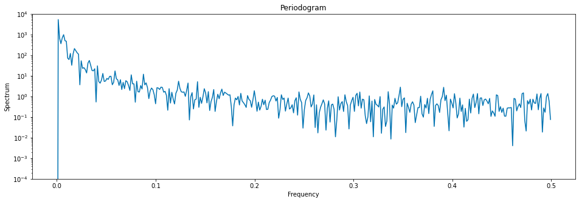

```python
plt.rcParams['figure.figsize'] = [16,5]
# Plot the spectral density
freqs, Pxx_den = periodogram(ts)
plt.semilogy(freqs, Pxx_den)
plt.ylim([1e-4, 1e4])
plt.title('Periodogram')
plt.xlabel('Frequency')
plt.ylabel('Spectrum')
plt.show()
plt.rcParams['figure.figsize'] = [16,10]
```

Scroll Up

### 2.6. Time Series Decomposition

> **Trend:**
> - The trend component represents the long-term pattern or direction of the data. In our case, the trend appears to be increasing over time, indicating a positive growth pattern.

> **Seasonal:**
> - The seasonal component represents the regular, repeating patterns within the data. In our case, the seasonal component shows fluctuations that occur with a periodicity of 365 days, indicating a yearly seasonality pattern.

> **Residual:**
> - The residual component represents the random or irregular fluctuations that cannot be explained by the trend or seasonal components. It captures the noise or unpredictable variations in the data.

#### Findings:

> - Based on the trend component, we can see that the values gradually increase over time, starting from around 6.8 and reaching 12.8 by the end of the observed period. This indicates a positive growth trend in the data.
> - The seasonal component shows the periodic fluctuations with an amplitude ranging from -2.8 to 2.8. These fluctuations follow a yearly pattern, suggesting a seasonality effect in the data.

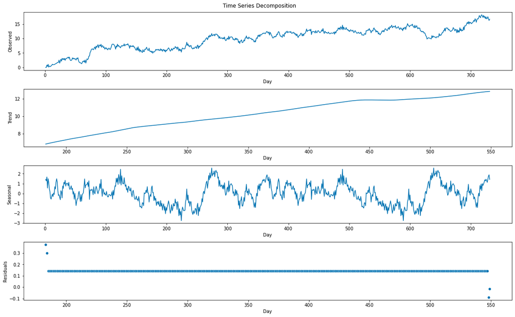

```python
# Visualize the seasonal decomposition
decomp = seasonal_decompose(ts, model='additive', period=365)

fig, ax = plt.subplots(4)
plt.suptitle('Time Series Decomposition')
sns.lineplot(data=decomp.observed, ax=ax[0])
ax[0].set_ylabel('Observed')
sns.lineplot(data=decomp.trend, ax=ax[1])
ax[1].set_ylabel('Trend')
sns.lineplot(data=decomp.seasonal, ax=ax[2])
ax[2].set_ylabel('Seasonal')
sns.scatterplot(data=decomp.resid, ax=ax[3])
ax[3].set_ylabel('Residuals')
plt.tight_layout()
```

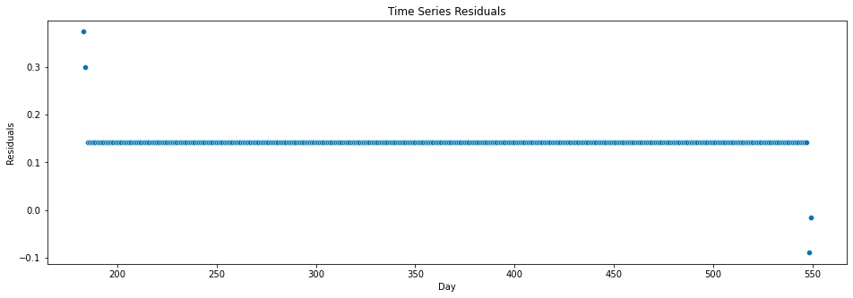

```python
plt.rcParams['figure.figsize'] = [16,5]
# Plot the residuals
sns.scatterplot(data=decomp.resid)
plt.title('Time Series Residuals')
plt.ylabel('Residuals')
plt.show()
plt.rcParams['figure.figsize'] = [16,10]
```

Scroll Up

### 2.7. ARIMA Modeling

> **Model Summary:**
> - We fitted the ARIMA model with the identified order (1, 1, 0) to the training data.
> - The summary provides information about the model's coefficients, standard errors, statistical significance, and goodness-of-fit measures.

> **Confidence Intervals:**
> - The confidence intervals provide a range of plausible values for each forecasted point. The lower and upper bounds of the 95% confidence intervals for the forecasted values are also provided.

> **Forecast Evaluation:**
> - To assess the accuracy of the forecast, we calculate the root mean squared error (RMSE) between the forecasted values and the actual test series.

Scroll Up

## 3. Forecast Prediction Interval

## > We chose the last 30 days in our time series as our forecast prediction interval, which is a common approach when working with time series data.

Scroll Up

## 4. Justification: Forecast Length

> **Recent Data:**  
> By selecting the last 30 days as the forecast prediction interval, we are using the most recent data available. This is often best because recent data may capture the most up-to-date trends and patterns in the time series. As a result, the forecast based on this recent data is expected to be more accurate.

> **Seasonality and Trends:**  
> Time series data often exhibit seasonality and trends. By using the last 30 days, we can better capture any recent seasonal patterns or trends that might be present in the data. This can lead to more accurate forecasts compared to using a longer time period that might include outdated or irrelevant patterns.

> **Adaptability:**  
> Time series data can be influenced by various factors, such as economic conditions, consumer behavior, or external events. By focusing on the last 30 days, we allow the model to adapt more quickly to any recent changes or shocks in the data. This adaptability can result in more accurate forecasts by considering the most relevant information for the forecast period.

## **Computational Efficiency:** Forecasting models often require computational resources and time to train and generate forecasts. Using a smaller prediction interval, such as the last 30 days, reduces the computational burden compared to using a longer time period. This can be particularly important when dealing with large or complex datasets.

Scroll Up

## 5. Model Evaluation Procedure

> 1. Split the time series data into a training set and a test set. The training set contains the majority of the data, while the test set consists of the most recent portion that will be used for evaluation.
> 2. Fit an ARIMA model using the training data. In this case, we use an ARIMA(1, 1, 0) model, indicating an autoregressive order of 1, a differencing order of 1, and a moving average order of 0.
> 3. Use the fitted ARIMA model to generate predictions for the test set. We call the get_forecast function to obtain the forecasted values, along with confidence intervals.
> 4. Evaluate the model by comparing the predicted values to the actual values in the test set. To quantify the average difference between the predicted and actual values, we calculate the Root Mean Squared Error (RMSE). The RMSE serves as an error metric for assessing the accuracy of our model.
> 5. Create two plots to visualize the results. The first plot shows the predicted means versus the test series, allowing for a visual comparison. The second plot includes the forecasted values, the test series, and the confidence intervals to visualize the uncertainty of our predictions.
> 6. Interpret the RMSE value as a measure of our model's performance. A lower RMSE suggests better accuracy, while a higher RMSE indicates larger prediction errors.

```python
# Split the train and test data
train = ts[:-30]
test = ts[-30:]
```

```python
# Create the ARIMA model with the identified order
model = ARIMA(train.reset_index(drop=True), order=(1,1,0))
model = model.fit()
model.summary()
```

SARIMAX Results

| Dep. Variable: | y | No. Observations: | 701 |
| --- | --- | --- | --- |
| Model: | ARIMA(1, 1, 0) | Log Likelihood | -466.837 |
| Date: | Tue, 06 Jun 2023 | AIC | 937.673 |
| Time: | 10:21:15 | BIC | 946.776 |
| Sample: | 0 | HQIC | 941.192 |
|  | - 701 |  |  |
| Covariance Type: | opg |  |  |

|  | coef | std err | z | P>\|z\| | [0.025 | 0.975] |
| --- | --- | --- | --- | --- | --- | --- |
| ar.L1 | -0.4712 | 0.033 | -14.142 | 0.000 | -0.537 | -0.406 |
| sigma2 | 0.2221 | 0.013 | 17.624 | 0.000 | 0.197 | 0.247 |

| Ljung-Box (L1) (Q): | 0.04 | Jarque-Bera (JB): | 1.44 |
| --- | --- | --- | --- |
| Prob(Q): | 0.85 | Prob(JB): | 0.49 |
| Heteroskedasticity (H): | 0.96 | Skew: | -0.00 |
| Prob(H) (two-sided): | 0.76 | Kurtosis: | 2.78 |

Warnings:  
[1] Covariance matrix calculated using the outer product of gradients (complex-step).

```python
# Predict the last month
fcast = model.get_forecast(steps=len(test))
fcast_vals = fcast.predicted_mean
ci = fcast.conf_int()
```

```python
# View predicted mean, observed mean, and difference between mean values
predicted = round(fcast_vals.mean(), 2)
observed = round(test.mean(), 2)

print(f'Predicted Mean: {predicted}')
print(f'Observed Mean: {observed}')
print(f'Difference: {round(predicted - observed, 2)}')
```

```
Predicted Mean: 15.21
Observed Mean: 16.87
Difference: -1.66
```

Scroll Up

### 5.1. Error Metric

## > The Root Mean Squared Error (RMSE) is a commonly used error metric for evaluating the performance of forecasting models, particularly in time series analysis. It measures the average magnitude of the differences between the predicted values and the actual values of the time series. A lower RMSE indicates a better fit of the model to the observed data. Therefore, a smaller RMSE value represents a more accurate forecasting model. Our RMSE value of 1.8317 suggests that, on average, the predictions from the ARIMA model are off by approximately 1.8317 units.

```python
# Calculate the root mean squared error
rmse = np.sqrt(mse(fcast_vals, test))
print(f'Root Mean Squared Error (RMSE): {rmse}')
```

```
Root Mean Squared Error (RMSE): 1.8316544171548799
```

Scroll Up

## 6. Visualization: Final Model Forecast vs Test Set

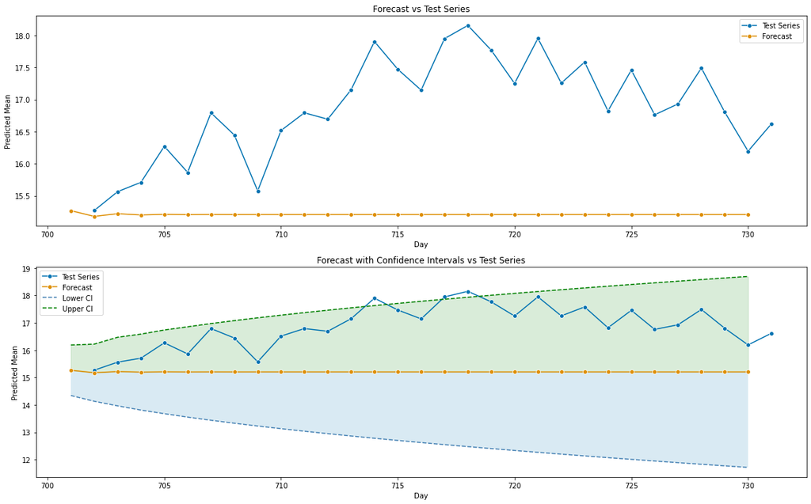

```python
fig, ax = plt.subplots(2)
# Plot the predicted means vs the test series
sns.lineplot(data=test, label='Test Series', marker='o', ax=ax[0])
sns.lineplot(data=fcast_vals, label='Forecast', marker='o', ax=ax[0])
ax[0].set_title('Forecast vs Test Series')
ax[0].set_ylabel('Predicted Mean')

# Plot the forecast with confidence intervals
sns.lineplot(data=test, label='Test Series', marker='o', ax=ax[1])
sns.lineplot(data=fcast_vals, label='Forecast', marker='o', ax=ax[1])
sns.lineplot(data=ci['lower y'], label='Lower CI', linestyle='--', color='#4682B4', ax=ax[1])
sns.lineplot(data=ci['upper y'], label='Upper CI', linestyle='--', color='green', ax=ax[1])

# Fill the space between the forecast and the confidence intervals
ax[1].fill_between(ci.index, ci['lower y'], fcast_vals, alpha=0.15)
ax[1].fill_between(ci.index, fcast_vals, ci['upper y'], alpha=0.15, color='green')

# Label the plot and axes
ax[1].set_title('Forecast with Confidence Intervals vs Test Series')
ax[1].set_xlabel('Day')
ax[1].set_ylabel('Predicted Mean')
plt.tight_layout()
```

Scroll Up

Scroll Up

## 8. Projected Revenue: Year 3, Month 1

```python
# Fit the model with the original data
model2 = ARIMA(ts.reset_index(drop=True), order=(1,1,0))
model2 = model2.fit()
```

```python
# Forecast the next 30 days with confidence intervals
fcast2 = model2.get_forecast(steps=30)
fcast_vals2 = fcast2.predicted_mean
ci2 = fcast2.conf_int()
```

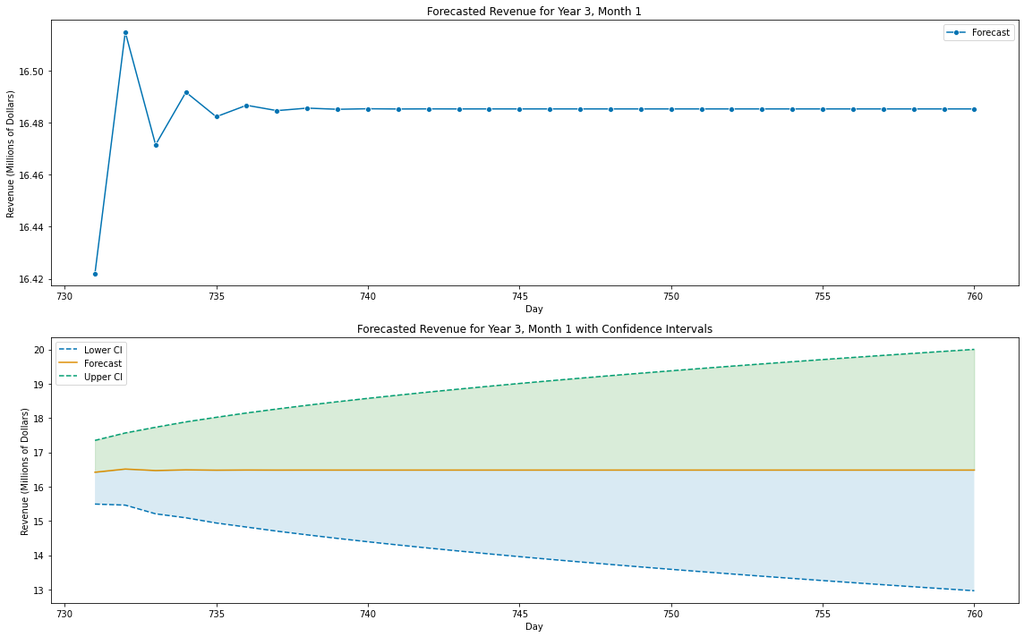

```python
fig, ax = plt.subplots(2)
# Plot the predictions
sns.lineplot(data=fcast_vals2, label='Forecast', marker='o', ax=ax[0])
ax[0].set_title('Forecasted Revenue for Year 3, Month 1')
ax[0].set_xlabel('Day')
ax[0].set_ylabel('Revenue (Millions of Dollars)')

# Plot the forecast with confidence intervals
sns.lineplot(x='index', y='lower y', data=ci2.reset_index(), linestyle='--', label='Lower CI', ax=ax[1])
sns.lineplot(data=fcast_vals2, label='Forecast', ax=ax[1])
sns.lineplot(x='index', y='upper y', data=ci2.reset_index(), linestyle='--', label='Upper CI', ax=ax[1])

# Fill the space between the forecast and the confidence intervals
ax[1].fill_between(ci2.index, ci2['lower y'], fcast_vals2, alpha=0.15)
ax[1].fill_between(ci2.index, fcast_vals2, ci2['upper y'], alpha=0.15, color='green')

# Label the plot and axes
ax[1].set_title('Forecasted Revenue for Year 3, Month 1 with Confidence Intervals')
ax[1].set_xlabel('Day')
ax[1].set_ylabel('Revenue (Millions of Dollars)')
plt.tight_layout()
```

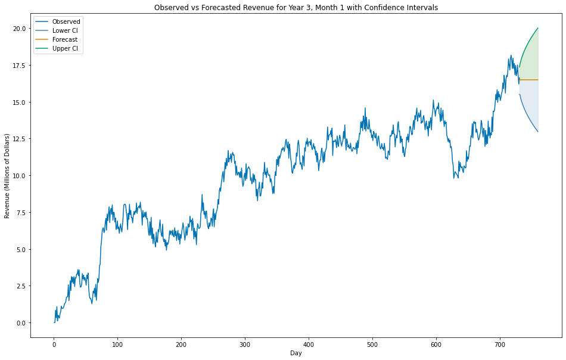

```python
# Plot the forecast with confidence intervals
sns.lineplot(data=ts, label='Observed')
sns.lineplot(x='index', y='lower y', data=ci2.reset_index(), color='#4682B4', label='Lower CI')
sns.lineplot(data=fcast_vals2, label='Forecast')
sns.lineplot(x='index', y='upper y', data=ci2.reset_index(), label='Upper CI')

# Fill the space between the forecast and the confidence intervals
plt.fill_between(ci2.index, ci2['lower y'], fcast_vals2, alpha=0.15, color='#4682B4')
plt.fill_between(ci2.index, fcast_vals2, ci2['upper y'], alpha=0.15, color='green')

# Label the plot and axes
plt.title('Observed vs Forecasted Revenue for Year 3, Month 1 with Confidence Intervals')
plt.xlabel('Day')
plt.ylabel('Revenue (Millions of Dollars)')
plt.show()
```

```python
# Isolate revenue for the first month of each year
temp = df[df.Month == 1]
year1 = temp[['Day', 'Revenue']][temp.Year == 1]
year2 = temp[['Day', 'Revenue']][temp.Year == 2]
year2['Day'] = range(1, len(year2)+1)
year3 = pd.concat([year1[['Day']], pd.Series(fcast_vals2).reset_index(drop=True)], axis=1)
year3.columns=['Day', 'Predicted Revenue']
```

```python
# Combine annual data for January
jan_df = pd.concat([
    year1[['Revenue']],
    year2[['Revenue']].reset_index(drop=True),
    year3[['Predicted Revenue']].reset_index(drop=True)
], axis=1)
jan_df.columns = ['1', '2', '3']
```

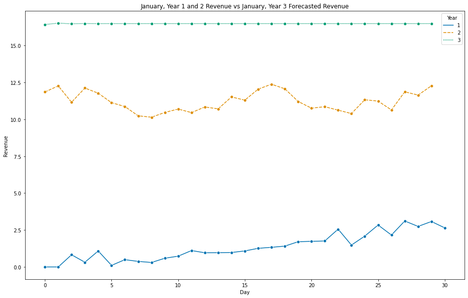

```python
# Plot the predictions vs year 1 and 2
sns.lineplot(data=jan_df, marker='o')
plt.title('January, Year 1 and 2 Revenue vs January, Year 3 Forecasted Revenue')
plt.xlabel('Day')
plt.ylabel('Revenue')
plt.legend(title='Year')
plt.show()
```

```python
# Get the annual sales revenue summary statistics
stats = jan_df.describe().drop('count')
stats
```

|  | 1 | 2 | 3 |
| --- | --- | --- | --- |
| mean | 1.350632 | 11.227294 | 16.483823 |
| std | 0.930770 | 0.669059 | 0.013199 |
| min | 0.000000 | 10.143207 | 16.422010 |
| 25% | 0.661383 | 10.699803 | 16.485259 |
| 50% | 1.111586 | 11.185097 | 16.485260 |
| 75% | 1.925452 | 11.830198 | 16.485261 |
| max | 3.113270 | 12.379342 | 16.514776 |

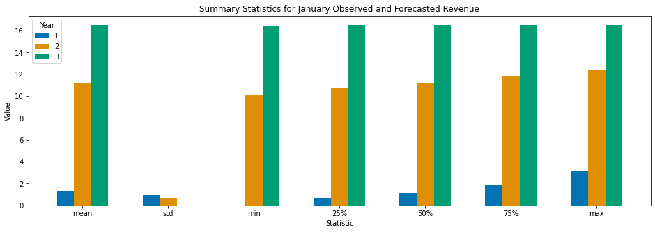

```python
plt.rcParams['figure.figsize'] = [16,5]
# Visualize the summary statistics
x = np.arange(len(stats))
width = 0.2
plt.bar(x-width, stats['1'], width, label='1')
plt.bar(x, stats['2'], width, label='2')
plt.bar(x+width, stats['3'], width, label='3')
plt.title('Summary Statistics for January Observed and Forecasted Revenue')
plt.xticks(x, stats.index)
plt.xlabel('Statistic')
plt.ylabel('Value')
plt.legend(title='Year')
plt.show()
plt.rcParams['figure.figsize'] = [16,10]
```

```python
jan1 = round(jan_df['1'].sum(), 2)
jan2 = round(jan_df['2'].sum(), 2)
predicted = round(jan_df['3'].sum(), 2)
```

```python
# Calculate the YoY observed and predicted growth
print('   January YoY Growth\n------------------------')
print('Year 2 Observed Revenue:',
      round(((jan2 - jan1) / jan1)*100, 2).astype(str)+'%')

print('Year 3 Predicted Revenue:',
    round(((predicted - jan2) / jan2)*100, 2).astype(str)+'%')
```

```
   January YoY Growth
------------------------
Year 2 Observed Revenue: 704.44%
Year 3 Predicted Revenue: 46.82%
```

```python
print(f'Year 2, Month 1 Observed Revenue: ${jan2} Million')
print(f'Year 3, Month 1 Predicted Revenue: ${predicted} Million')
print(f'Expected Revenue Increase: ${predicted - jan2} Million')
```

```
Year 2, Month 1 Observed Revenue: $336.82 Million
Year 3, Month 1 Predicted Revenue: $494.51 Million
Expected Revenue Increase: $157.69 Million
```

> Based on our forecast for January, Year 3, Teleco can expect to see an average increase in revenue of 46.82% from January, Year 2, a $157.69 Million increase in revenue.